# Reproducible Research Course Project 1

Carlos Gutierrez Sanchez del Rio

## Loading and preprocessing the data

```r
if(!file.exists("activity.csv")) {
  # Unzip the data
  unzip("repdata-data-activity.zip")
}

activity_data<-read.csv("activity.csv", stringsAsFactors=FALSE)
```

Now we need to process the date column as a Date format:

```r
activity_data$date<-as.Date(activity_data$date)
```

## What is mean total number of steps taken per day?

First we need to calculate the total number of steps taken per day by using tapply and ignoring NA values (for this part of the assignment we will ignore the missing values in the dataset). Then we will plot an histogram of the total number of steps taken each day (we include a “rug” to see where the data is concentrated).

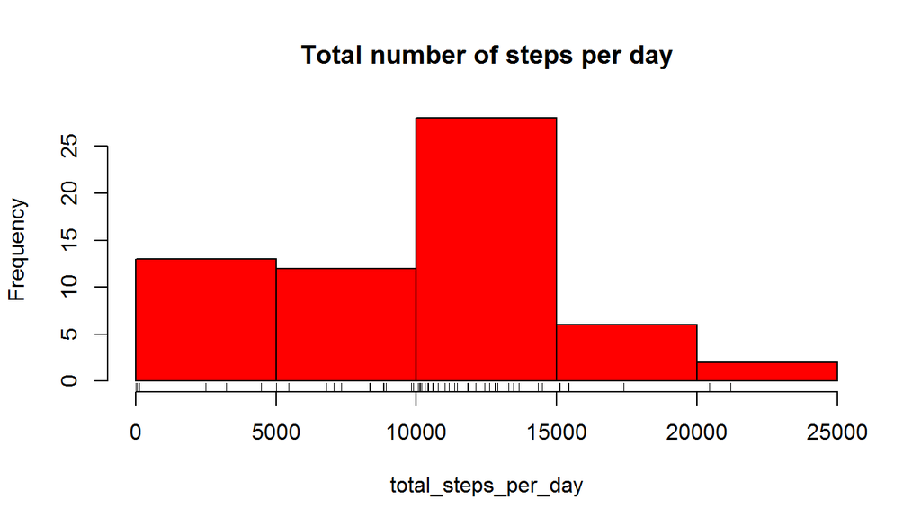

```r
total_steps_per_day<-tapply(activity_data$steps,activity_data$date,sum,na.rm=TRUE)
hist(total_steps_per_day,main="Total number of steps per day",col="red")
rug(total_steps_per_day)
```

Once we have the total number of steps taken per day, we can calculate the mean and the median of the total steps per day:

```r
mean_total_steps<-round(mean(total_steps_per_day,na.rm = TRUE),digits=0)
median_total_steps<-round(median(total_steps_per_day,na.rm = TRUE),digits=0)
```

We can see that the mean is 9354 per day and the median is 10395

## What is the average daily activity pattern?

In order to investigate the average daily pattern, we will now make a plot of the average steps taken per interval (0-2355) across all days:

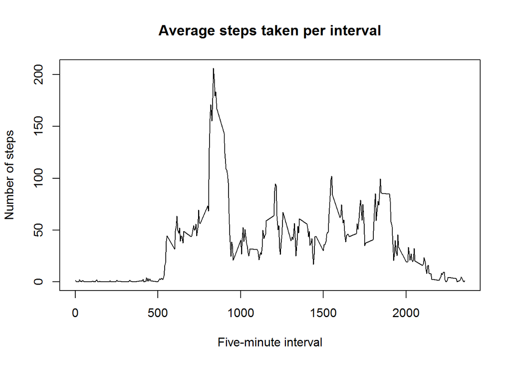

```r
total_steps_per_interval<-as.data.frame(cbind(unique(activity_data$interval),tapply(activity_data$steps,activity_data$interval,mean,na.rm=TRUE)))
colnames(total_steps_per_interval)<-c("interval","steps")

plot(total_steps_per_interval$interval,total_steps_per_interval$steps,type="l",xlab="Five-minute interval",ylab="Number of steps",main="Average steps taken per interval")
```

```r
# calculate the maximum
max_daily_steps<- total_steps_per_interval[which.max(total_steps_per_interval$steps),2]
max_daily_steps_interval<- total_steps_per_interval[which.max(total_steps_per_interval$steps),1]
```

We can now say that, on average, the 5-minute interval number 835 contains the maximum number of steps (206.1698113)

## Imputing missing values

There are a number of days/intervals where there are missing values (coded as NA). The presence of missing days may introduce bias into some calculations or summaries of the data.

```r
NAs_index<-is.na(activity_data$steps)
num_NAs<-sum(NAs_index)
```

The number of missing values is 2304, so we need to fill the missing data with the *mean for the corresponding 5-minute interval*. We will create a new dataset that is equal to the original dataset but with the missing data filled in. For taht we first merge the activity data with the data frame containing the 5min interval mean, and then we replace the missing values with the mean value for the interval.

```r
activity_data_imputed<- merge(activity_data,total_steps_per_interval,by="interval",all.x=TRUE,all.y = FALSE)
activity_data_imputed[is.na(activity_data_imputed$steps.x),2]<-activity_data_imputed[is.na(activity_data_imputed$steps.x),4]
activity_data_imputed$steps.y<-NULL
names(activity_data_imputed)[2] <- "steps"
```

We will now plot a histogram of the total number of steps taken each day comparing the results from the filled-in dataset and the previous situation (without taking into account the missing values)

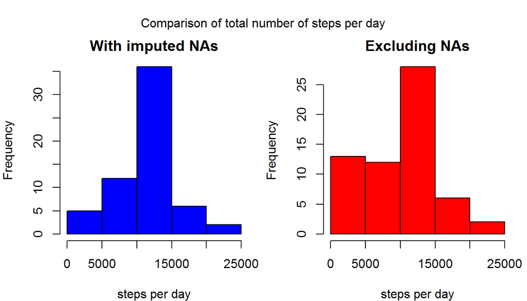

```r
par(mfrow = c(1, 2),mar = c(4, 4, 2, 1), oma = c(0, 0, 2, 0))
total_steps_per_day_imputed<-tapply(activity_data_imputed$steps,activity_data_imputed$date,sum,na.rm=TRUE)
hist(total_steps_per_day_imputed,main="With imputed NAs",col="blue",xlab="steps per day")
hist(total_steps_per_day,main="Excluding NAs",col="red",xlab="steps per day")
mtext("Comparison of total number of steps per day",outer=TRUE)
```

After comparing both plots, we can calculate and report the mean and median total number of steps taken per day:

```r
mean_total_steps_imputed<-round(mean(total_steps_per_day_imputed,na.rm = TRUE),digits=0)
median_total_steps_imputed<-round(median(total_steps_per_day_imputed,na.rm = TRUE),digits=0)
```

We can see that in both cases, the mean (10766) and the median (10766) after imputing the NA values **increases** vs the previous situation.

## Are there differences in activity patterns between weekdays and weekends?

In order to investigate if there are differences in activity patterns between weekdays and weekends we will create a new factor variable in the dataset with two levels - “weekday” and “weekend” indicating whether a given date is a weekday or weekend day.

```r
Sys.setlocale("LC_TIME", "English") # This is needed for a non-english install
```

```
## [1] "English_United States.1252"
```

```r
activity_data_imputed$type_of_day <- as.factor(ifelse(weekdays(activity_data_imputed$date) %in% c("Saturday","Sunday"), "Weekend", "Weekday"))
```

Now we can plot the difference in activity patterns for each 5-minute interval (x-axis) and the average number of steps taken, averaged across all weekday days or weekend days:

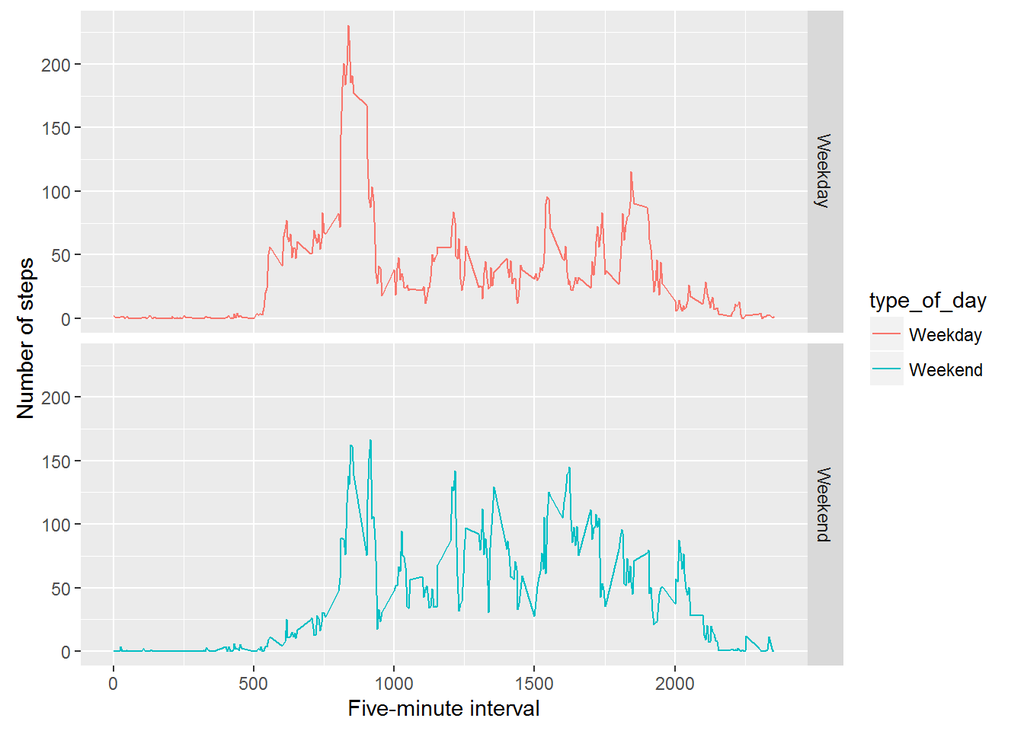

```r
library(ggplot2)
mean_steps_per_interval_imputed<-aggregate(steps ~ interval + type_of_day, data=activity_data_imputed, mean)
ggplot(mean_steps_per_interval_imputed, aes(interval, steps)) + geom_line(aes(color=type_of_day)) + facet_grid(type_of_day ~ .) +
    xlab("Five-minute interval") + ylab("Number of steps")
```